# Penguin_Analysis

Susan Johnston

2/27/2024

Here is a comment to show that I am using git!

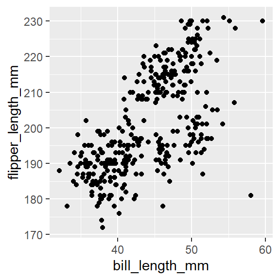

Now to do some analysis…

## Introduction

Three species of penguins are found on three islands in the Palmer archipelago in Antarctica (Figure 1). This study will investigate variation in bill morphology in one of these species, the Adelie penguin.

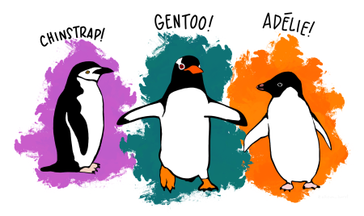

Figure 1. Three species of Palmer penguins.

## Methods

Penguin bill length and bill depth were measured in mm using calipers. The correlation between the measures was investigated using a linear regression. We also investigated sex differences in bill depth using a t-test.

## Results

Bill depth increased with bill length:

```
##
## Call:
## lm(formula = bill_depth_mm ~ bill_length_mm, data = penguins_edit)
##
## Residuals:
##     Min      1Q  Median      3Q     Max
## -2.1512 -0.8012 -0.0698  0.5766  3.5032
##
## Coefficients:
##                Estimate Std. Error t value Pr(>|t|)
## (Intercept)    11.40912    1.33893   8.521 1.61e-14 ***
## bill_length_mm  0.17883    0.03444   5.193 6.67e-07 ***
## ---
## Signif. codes:  0 '***' 0.001 '**' 0.01 '*' 0.05 '.' 0.1 ' ' 1
##
## Residual standard error: 1.123 on 149 degrees of freedom
##   (1 observation deleted due to missingness)
## Multiple R-squared:  0.1533, Adjusted R-squared:  0.1476
## F-statistic: 26.97 on 1 and 149 DF,  p-value: 6.674e-07
```

OR…

Bill depth increased with bill length (intercept = 11.4091245, slope = 0.1788343, P = 6.6741409^{-7}, Adjusted R<sup>2</sup> = 0.147583, Figure 2)

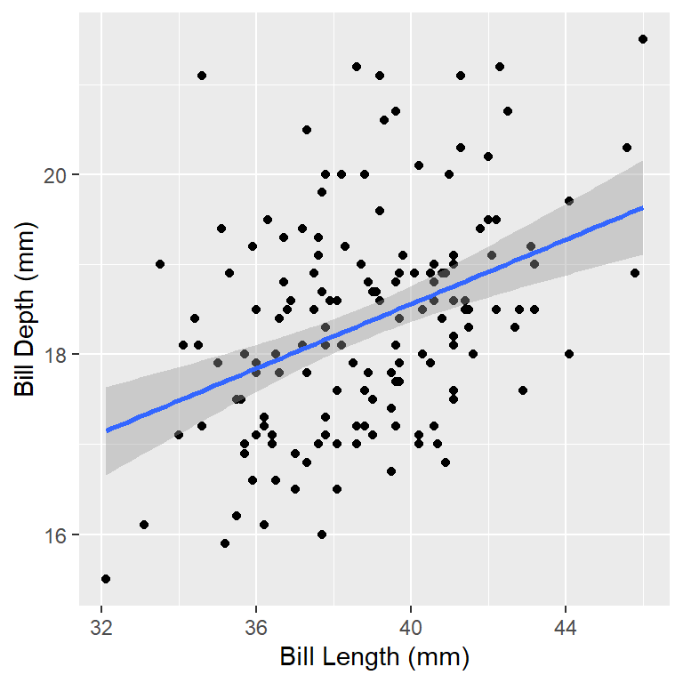

Figure 2: Linear regression of bill depth and bill length

We also saw clear sex differences in bill depth, where males had deeper bills than females (t = -8.927971, df = 143.1457242, P = 1.9140926^{-15}, Figure 3)

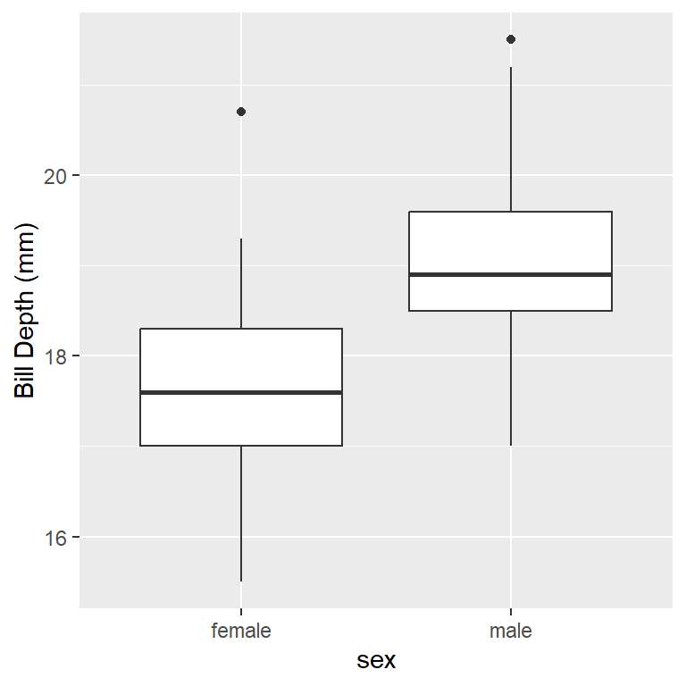

Figure 3: Boxplot of bill depth by sex.

## Dicussion

We showed that bill length and depth are correlated, and that there is significant sexual dimorphism in this trait in Adelie penguins.